# Final Analysis

Team 3

2/15/2021

```r
choco <- read.csv("https://raw.githubusercontent.com/xdaiISU/ds202materials/master/hwlabs/data/choco.csv")
```

# Bean Origin vs Rating

To get a general overview of what locations produce the cacao beans which taste the best on average, we can box plot the rating property, categorizing by bean origin:

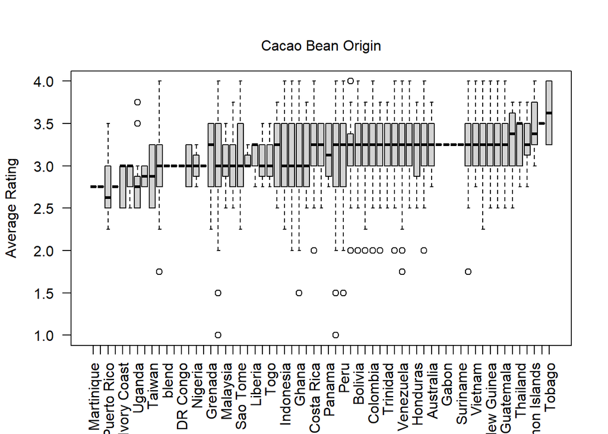

```r
types <- reorder(choco$Bean_Origin, choco$Rating, FUN=mean)
boxplot(choco$Rating ~ types, las=2, ylab='Average Rating', xlab='')
mtext('Cacao Bean Origin', side=3, line=1)
```

However, if we want to know just where the best beans come from (i.e., beans that produce chocolates which having a rating of 4.0), we can filter down the dataset to only chocolates with the highest rating and show them in a table or barplot:

```r
# Want bar chart of all 4.0 ratings by location
best <- choco[choco$Rating == 4.0,]
best_grouped <- sort(table(best$Bean_Origin))
best_grouped
```

```
##
##        Indonesia          Jamaica         Sao Tome  Solomon Islands
##                1                1                1                1
##        St. Lucia         Tanzania           Tobago          Vietnam
##                1                1                1                1
##           Belize       Costa Rica            Ghana        Nicaragua
##                2                2                2                2
##        Guatemala            Haiti           Mexico           Brazil
##                3                3                3                4
## Papua New Guinea          Bolivia         Colombia            Blend
##                4                5                5                7
##          Ecuador       Madagascar             Peru        Venezuela
##                8               10               16               18
```

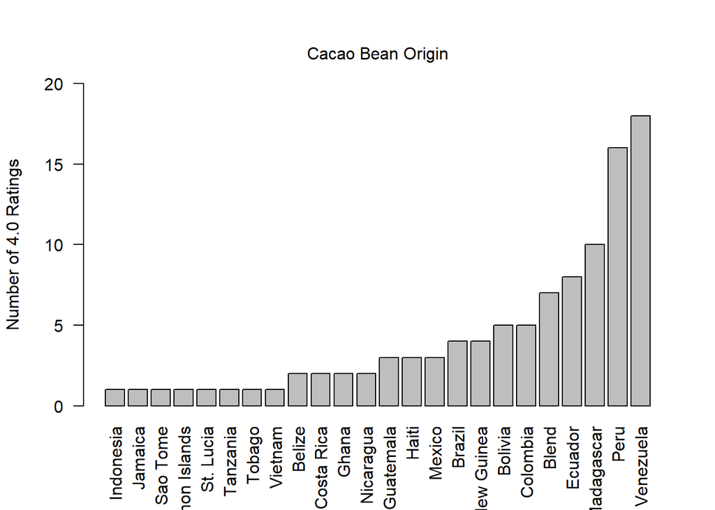

```r
barplot(best_grouped, las=2, ylab='Number of 4.0 Ratings', ylim=c(0,20))
mtext('Cacao Bean Origin', side=3, line=1)
```

So although Tobago produced on average the highest rated chocolates, we could guess that this is because there are few data points i.e. chocolates tested from Tobago.

We can confirm this by showing how many chocolates were tested whose beans originated from Tobago:

```r
table(choco$Bean_Origin)['Tobago']
```

```
## Tobago
##      2
```

Only 2 chocolates from Tobago were tested, which explains the extremely high average.

Venezuela on the other hand, as can be seen in the bar chart, produced beans for 18 chocolates which were rated 4.0. We can see where Venezuela lies on average

```r
types <- reorder(choco$Bean_Origin, choco$Rating, FUN=function(x) -mean(x))
mean_ratings <- aggregate(choco$Rating ~ types, FUN=mean)
mean_ratings
```

```
##                    types choco$Rating
## 1                 Tobago     3.625000
## 2    Sao Tome & Principe     3.500000
## 3        Solomon Islands     3.450000
## 4                  Congo     3.318182
## 5               Thailand     3.300000
## 6                   Cuba     3.291667
## 7              Guatemala     3.273585
## 8                  Haiti     3.270833
## 9       Papua New Guinea     3.270408
## 10            Madagascar     3.260736
## 11               Vietnam     3.253906
## 12                Brazil     3.253333
## 13             Australia     3.250000
## 14                Bolvia     3.250000
```

[output cut: 49 more lines]

We can see that Venezuela is rated 21st on average even though it has the most 4.0 ratings.